# Analyse van Gen Expressie verschillen tussen en Lever weefsels

Kerem Senturk

2026-03-04

## Onderzoekvraag

Is er een verschillende genesxpressie tussen Lever en Brain en welke biologische proccessen erbij betrokken zijn? ### Deelvraag Hoe kunnen de verschillen in genexpressie visueel worden weergegeven?

## Overkoepelend Doel van het RNA-seq analyse

In dit project wordt onderzocht welke genen verschillend tot expressie komen tussen hersenweefsel en leverweefsel. De onderzoeksvraag luidt: welke verschillen in genexpressie zijn aanwezig tussen hersen- en leverweefsel en welke biologische processen hangen hiermee samen?

Om deze vraag te beantwoorden wordt RNA-seq data geanalyseerd. De reads worden uitgelijnd tegen een referentiegenoom en samengevat in een counttabel, waarna een differentiële genexpressieanalyse wordt uitgevoerd. Vervolgens wordt een GO-term enrichment analyse toegepast om inzicht te krijgen in de biologische functies en processen die samenhangen met de gevonden expressieverschillen. ## Toelichting van Alignment Voor de alignment zijn de FASTQ-bestanden van lever- en hersenweefsel uitgelijnd tegen het humane referentiegenoom hg38 met de functie align() uit het Rsubread pakket. Hiervoor is een vooraf gegenereerde hg38-index gebruikt. De zes FASTQ-bestanden (drie lever en drie brein) zijn meegegeven via readfile1, zodat elke sample apart wordt uitgelijnd.

Omdat het om RNA-seq data gaat, is type = 0 ingesteld zodat het juiste mappingprotocol voor RNA wordt toegepast. De inputbestanden zijn gzipped FASTQ-bestanden (input_format = “gzFASTQ”) en de resultaten zijn opgeslagen als BAM-bestanden (output_format = “BAM”).

Met unique = TRUE zijn alleen reads meegenomen die op één duidelijke plek in het genoom mappen. Reads die op meerdere locaties kunnen mappen zijn uitgesloten, zodat elke read eenduidig wordt toegewezen. De alignment statistieken zijn opgeslagen in het object alignment_statistics voor verdere analyse.

Het is uitgesloten om abiquiteit (op het meerdere passen van de sequencing reads) te verminderen zodat elke read eenduidig toegewezen wordt. multi mapping reads kunnen onzzekerheid veroorzaken in de kwantificatie. van gen expressie. Aligner weet dan niet op welke plek de read echt hoort. Door uitsluitend unique gemapte reads te behouden wordt de betrouwbaarheid van downstream analyse verhoogd.

## Analyse van de Alignment statistieken

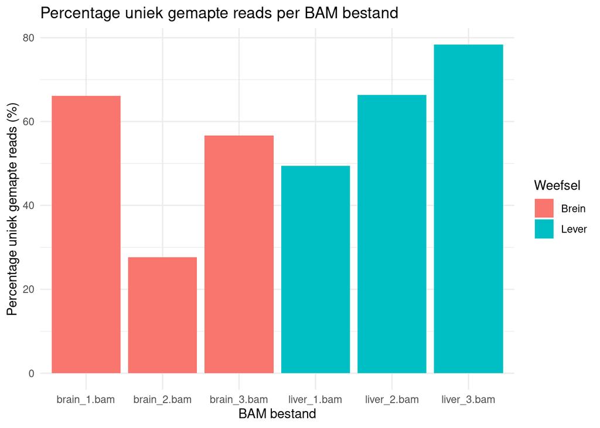

Figuur 1: Uniek gemapte reads per BAM bestand voor brein- en lever weefsel.

In figuur 1 zijn per BAM bestand het percentage uniek gemapte reads te zien. Hierbij valt op dat de percentages tussen de twee weefsels verschillen. De levermonsters laten waarden zien tussen ongeveer 49% en 78%, terwijl de hersenmonsters waarden laten zien tussen ongeveer 28% tot 66%. Daarnaast is binnen beide weefseltypes spreiding tussen replicaten zichtbaar.

## Conclusie van de alignmentstatistieken

Uit de alignment statistieken blijkt dat het percentage uniek gemapte reads verschilt tussen de verschillende BAM-bestanden. Zowel binnen de lever- als de breinmonsters is spreiding zichtbaar. Een paar samples hebben een duidelijk lager percentage dan andere. Dit laat zien dat de alignmentkwaliteit niet voor alle monsters gelijk is.

# Count tabel en data inspectie

## Toelichting van Count tabel en data inspectie

In deze analyse wordt een count tabel gegenereerd uit RNA-seq alignments met behulp van featureCounts. Vervolgens wordt deze tabel omgezet naar een DESeqDataSet om verdere analyse mogelijk te maken. De data wordt geïnspecteerd met PCA en een correlatieheatmap om te bepalen of samples van hetzelfde weefsel op elkaar lijken.

## DATA inspectie mbv correlatieheatmap en PCA

```
## Importance of components:
##                             PC1     PC2     PC3      PC4     PC5       PC6
## Standard deviation     127.5556 75.4394 53.7226 32.73632 27.7228 4.994e-14
## Proportion of Variance   0.6097  0.2132  0.1081  0.04016  0.0288 0.000e+00
## Cumulative Proportion    0.6097  0.8229  0.9311  0.97120  1.0000 1.000e+00
```

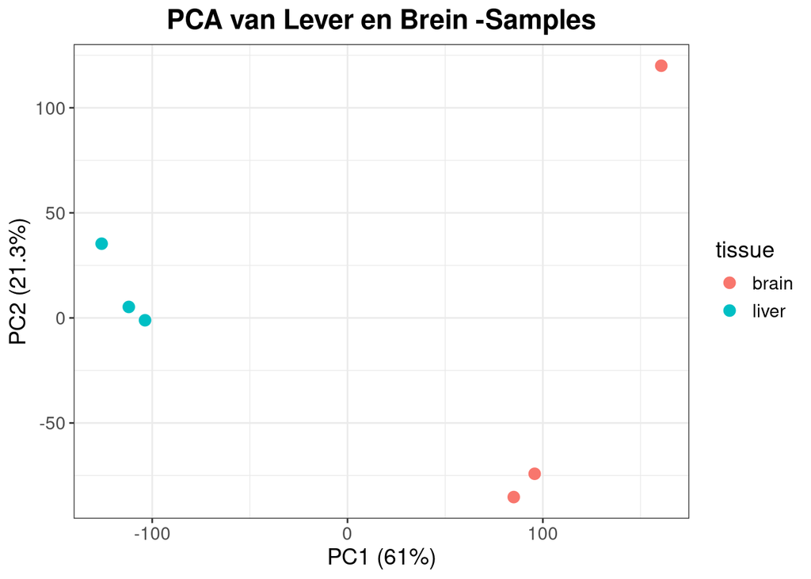

### Principal Component Analyse(PCA) van RNA seq-data FIGUUR 2:Zoals te zien bij FIGUUR 2 dat de samples clusteren op basis van weefseltype. De lever samples vormen een duidelijk cluster dat gescheiden is van de hersensamples. Dit suggereert dat de genexpressieprofielen tussen de twee weefsels verschillen.Dat wordt ook begrepen door de afstand tussen de groepering van de weefsels langs de PC1.

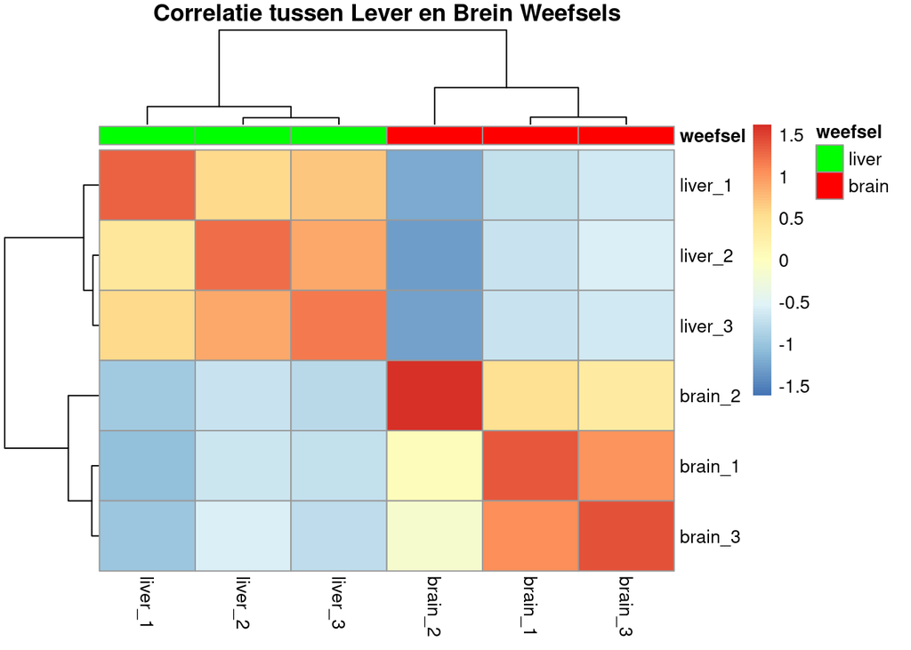

FIGUUR 3:Zoals te zien bij Figuur 3 dat De correlatieheatmap laat zien hoe sterk de genexpressieprofielen van de samples met elkaar correleren. Uit de heatmap blijkt dat de samples duidelijk clusteren op basis van weefseltype. De lever samples (liver) vormen een aparte cluster en vertonen een hoge correlatie met elkaar, terwijl de hersensamples (brain) ook samen clusteren. De correlatie tussen verschillende weefsels is lager, wat wijst op duidelijke verschillen in genexpressieprofielen tussen lever- en hersensamples. Dit resultaat ondersteunt dat het weefseltype een belangrijke bron van variatie is in de dataset. ## CONCLUSIE Beide figuren laten zien dat de samples clusteren op basis van weefseltype.Replicaten binnen dezelfde weefsel vertonen sterke overeenkomst,terwijl lever en breinweefsel duidelijk van elkaar verschillen in gen expressie.Dit wijst op consistente metingen en duidelijke biologische verschillen tussen de twee weefsels.

# DGE ANALYSE UITVOEREN

## “Introductie: RNA-seq en Differential Gene Expression Analyse”

RNA sequencing (RNA-seq) is een techniek die gebruikt wordt om de expressie van genen in een cel of weefsel te meten. Met deze methode kan worden bepaald hoeveel RNA er van elk gen aanwezig is, wat een indicatie geeft van hoe actief een gen is. Door RNA-seq data van verschillende samples met elkaar te vergelijken, kan worden onderzocht welke genen verschillend tot expressie komen onder verschillende omstandigheden of in verschillende weefsels. Een veelgebruikte methode om dit te analyseren is Differential Gene Expression (DGE) analyse. Met een DGE analyse wordt getest welke genen significant meer of minder tot expressie komen tussen twee groepen samples. In deze opdracht wordt hiervoor gebruik gemaakt van het R-package DESeq2. Dit programma gebruikt statistische modellen om verschillen in genexpressie te berekenen en bepaalt voor elk gen onder andere de log2 fold change en een adjusted p-waarde. Het doel van deze analyse is om genen te identificeren die significant up- of downgereguleerd zijn tussen de onderzochte weefsels. De resultaten van de analyse worden vervolgens gevisualiseerd met een volcano plot en een heatmap, zodat de verschillen in genexpressie duidelijk zichtbaar worden.

## Volcano Plot

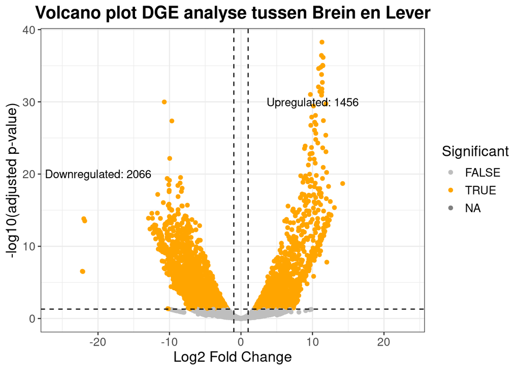

FIGUUR 4:Zoals te zien is in Figuur 4, wordt het verschil in genexpressie tussen lever- en breinsamples weergegeven. In totaal zijn 1456 genen upregulated (rechterkant van de plot) en 2066 genen downregulated (linkerkant van de plot). Dit betekent dat de genen aan de rechterkant hogere expressie vertonen in lever, terwijl de genen aan de linkerkant lagere expressie in lever hebben en dus hogere expressie in brain. Oranje punten geven de significante genen weer , terwijl grijze punten de niet-significante genen representeren. De verticale stippellijnen geven de log2 fold change thresholds van −1 en +1 aan, en de horizontale stippellijn toont de p-value cutoff (padj = 0.05). ## Heatmap

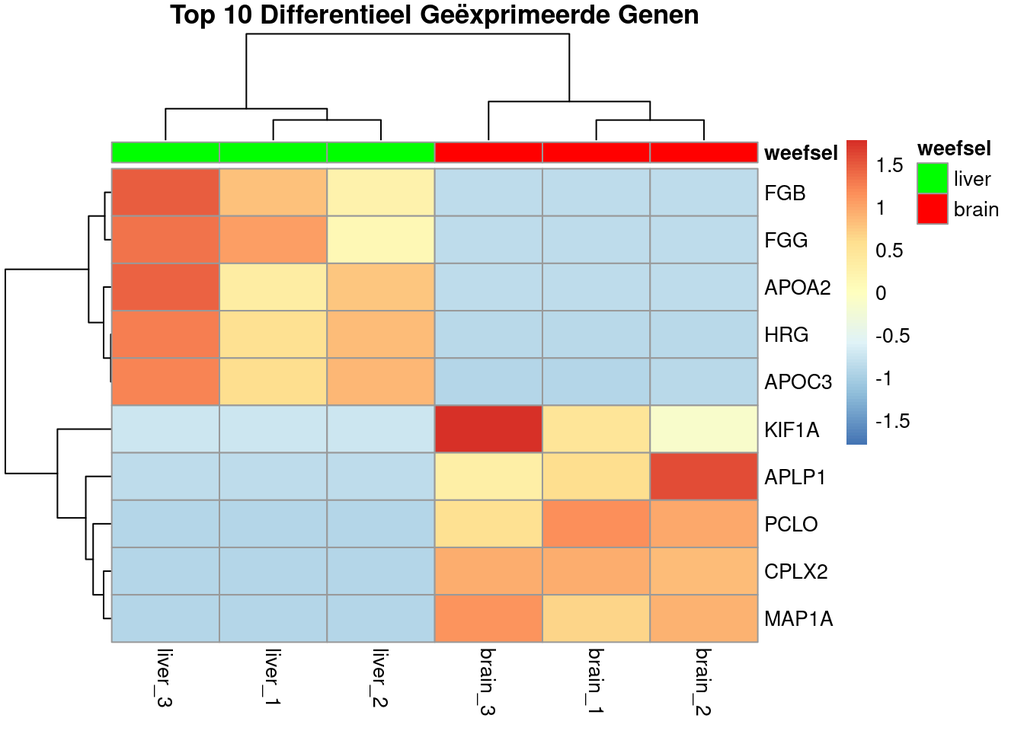

FIGUUR 5:Zoals te zien in Figuur 5, toont de heatmap de genormaliseerde expressie van de vijf meest upgereguleerde en de vijf meest downgereguleerde genen die significant differentieel tot expressie komen tussen lever- en breinsamples. Samples van hetzelfde weefsel clusteren samen, wat aangeeft dat replicaten vergelijkbare genexpressie vertonen. Genen die upregulated zijn in lever vertonen hogere expressie in lever, terwijl downregulated genen hogere expressie vertonen in brain. Rood geeft hoge expressie aan, blauw lage expressie.Er wordt gezien bijvoorbeeld APLP1 bij Brain 2 het meest tot expressie gekomen is.

# CONCLUSIE

Beide Visualisaties(Volcanoplot en Heatmap)bevestigen dat er duidelijke verschillen in genexpressie bestaan tussen lever- en breinsamples.De volcano plot visualiseert welke genen significant up- of downgereguleerd zijn en welke de grootste verschillen in expressie vertonen tussen lever- en breinsamples., terwijl de heatmap laat zien hoe deze genen zich gedragen over de individuele samples.Samen ondersteunen ze de betrouwbaarheid van de DGE-analyse en geven ze inzicht in weefsel-specifieke expressiepatronen die mogelijk biologische relevantie hebben.

# GO-term analyse

## Toelichting op de GO-term analyse

Om beter te begrijpen welke biologische functies en processen betrokken zijn bij de genen die verschillend tot expressie komen tussen de twee weefsels, voeren we een GO-term (Gene Ontology) enrichment analyse uit. Deze analyse identificeert GO-termen die oververtegenwoordigd zijn in de genenlijsten, waardoor we inzicht krijgen in de mogelijke biologische betekenis van de differentieel tot expressie komende genen.

De genen zijn geselecteerd op basis van hun differentiële expressie: ### Upregulated genen: genen met een adjusted p-waarde < 0.01 en een log fold change (LFC) > 1. Deze genen komen significant hoger tot expressie in het ene weefsel. ### Downregulated genen: genen met een adjusted p-waarde < 0.01 en een LFC < -1. Deze genen komen significant lager tot expressie.

## R Functies en Pakket

Er werd eerst new functie toegepast hiermee werd er GOdata-object aangemaakt waarin informatie over genenlijst,het type GO termen(biologische process)en de achtergrondset van genen wordt opgeslagen. Dit object vormt de basis voor de enrichmentsanalyse.

Ten tweede werd er HyperGtest toegepast. Hiermee voeren we een hypergeometrische test uit om te bepalen welke GO-termen significant verrijkt zijn in onze genenlijst. Deze test vergelijkt de frequentie van genen die bij een bepaalde GO-term horen in onze lijst met de frequentie in de achtergrondset, en berekent een p-waarde voor overrepresentatie.

```r
# Filter upregulated genen (LFC > 1 en padj < 0.01)
up_genes <- res_df[res_df$log2FoldChange > 1 & res_df$padj < 0.01, ]

# Filter downregulated genen (LFC < -1 en padj < 0.01)
down_genes <- res_df[res_df$log2FoldChange < -1 & res_df$padj < 0.01, ]
```

```r
# Haal de gen-ID's van up- en downregulated genen op
up_gene_ids <- rownames(up_genes) # Rownames van upregulated genen
down_gene_ids <- rownames(down_genes)# Rownames van downregulated genen
gene_universe <- rownames(res_df) # Universe van alle genen in je dataset (achtergrondlijst)

# Parameters instellen voor GO overrepresentatie test (upregulated genen)
params_up <- new(
  "GOHyperGParams", # Klasse voor GO Hypergeometric test
  geneIds = up_gene_ids,  # Gen-ID's van interesse
  universeGeneIds = gene_universe,# Achtergrondset van genen
  ontology = "BP",#  Biologische processen
  annotation = "org.Hs.eg.db", # Annotatie database (menselijk)
 pvalueCutoff = 0.01, # Significantie drempel
  conditional = FALSE,# Geen conditionele correctie op GO structuur
  testDirection = "over" # Test op overrepresentatie
)
go_up <- hyperGTest(params_up) # Voer de GO overrepresentatie test uit voor upregulated genen


#  Parameters instellen voor GO overrepresentatie test (downregulated genen)
params_down <- new(
  "GOHyperGParams",
  geneIds = down_gene_ids,
  universeGeneIds = gene_universe,
  annotation = "org.Hs.eg.db",
   ontology = "BP",
  pvalueCutoff = 0.01,
  conditional = FALSE,
  testDirection = "over"
)
go_down <- hyperGTest(params_down) # Voer de GO overrepresentatie test uit voor downregulated genen


# Upregulated GO resultaten
go_up_res <- summary(go_up)

# Downregulated GO resultaten
go_down_res <- summary(go_down)

top20_go_up <- head(go_up_res[order(go_up_res$Pvalue), ], 20) # Top 20 upregulated GO-termen
top20_go_down <- head(go_down_res[order(go_down_res$Pvalue), ], 20) # Top 20 downregulated GO-termen
```

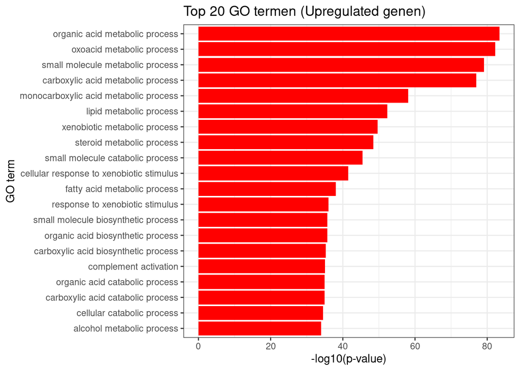

```r
# Maak een horizontale barplot van de top 20 upregulated GO-termen
ggplot(top20_go_up, aes(x = reorder(Term, -log10(Pvalue)), # Reorder de GO-termen op basis van -log10(p-value) (hoogste bovenaan)
                        y = -log10(Pvalue))) + # De hoogte van de balk = -log10(p-value)
  geom_bar(stat = "identity",fill="red") +  # Maak een staafdiagram; kleur rood
  coord_flip() + # Draai de assen, zodat de termen op de y-as komen
  labs(
    title = "Top 20 GO termen (Upregulated genen)",# Plot titel
    x = "GO term",# Label van x-as (hier horizontaal door coord_flip)
    y = "-log10(p-value)" # Label van y-as
  ) +
  theme_bw() # Gebruik een strak zwart-wit thema voor de plot
```

FIGUUR 6:Zoals te zien bij FIGUUR 6 dat er 20 meest verrijkte GO termen van upregulated genen weergegeven.De Y-as toont de GO termen(biologische processen).De X-as toont -log10(p-value), wat aangeeft hoe significant de verrijking is.Hoe hoger de balk, hoe sterker de overrepresentatie.Er werd ook gezien volgens de grafiek dat Organic acid metabolik proces en oxoacid metabolic process meer verrijkt is ten opzichte van andere.Dat betekent dat genen die met die functies betrokken zijn meer aktief zijn in lever.

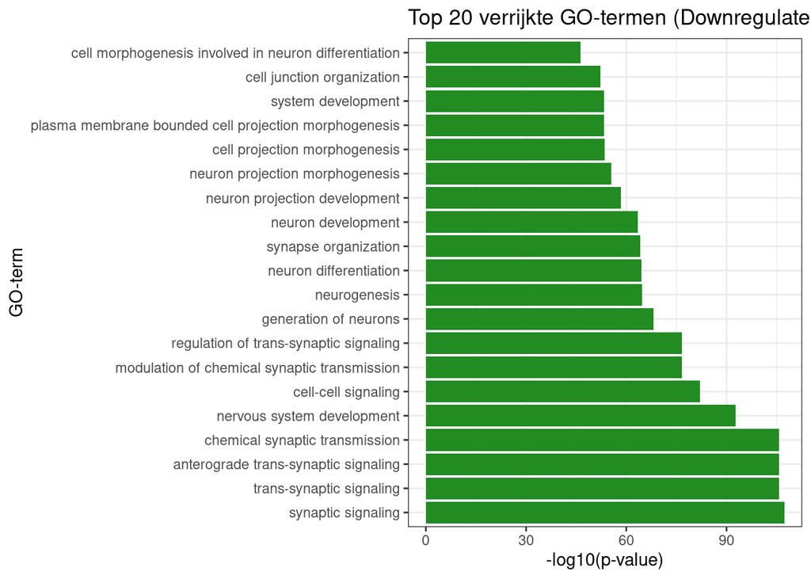

```r
# Maak een horizontale barplot van de top 20 downregulated GO-termen
ggplot(top20_go_down, aes(x=reorder(Term, Pvalue), # Sorteer GO-termen op Pvalue (kleinste bovenaan)
                          y=-log10(Pvalue))) + # De hoogte van de balk = -log10(p-value) voor betere schaal
  geom_bar(stat="identity", fill="forestgreen") +# Staafdiagram; kleur groen voor downregulated genen
  coord_flip() + # Draai de assen, zodat termen op de y-as komen

  labs(
    title="Top 20 verrijkte GO-termen (Downregulated genen)",# Titel van de plot
    x="GO-term",# Label van x-as (horizontaal door coord_flip)
    y="-log10(p-value)" # Label van y-as
  ) +
  theme_bw() # Gebruik een strak zwart-wit thema voor een professionele look
```

FIGUUR 7:Zoals te zien bij FIGUUR 7 er 20 meest verrijkte GO termen van downregulated genen weergegeven.De Y-as toont de GO termen(biologische processen).De X-as toont -log10(p-value), wat aangeeft hoe significant de verrijking is.Hoe hoger de balk, hoe sterker de overrepresentatie.Er werd ook gezien volgens de grafiek dat synpaptic signaling en trans-synaptic signaling meer verrijkt is ten opzichte van anderen Dat betekent dat genen die met die functies betrokken zijn minder aktief zijn in lever en meer aktief in brain.

## Conclusie van GO-term analyse

# Conclusie van de analyse van genexpressieverschillen tussen hersen- en leverweefsel

In Deze Project wordt bestudeerd. Is er een verschillende genexpresssie tussen Hersen en lever en Welke biologische processen erbij betrokken zijn .Het bleek uit meerdere lijnen van bewijs: -Alignment en Data Kwaliteit:Het percentage uniek aligned reads varieert tussen monsters, maar over het algemeen zijn er voldoende betrouwbare reads om downstream analyses uit te voeren. -Clustering en PCA:Zowel de PCA als de correlatieheatmap tonen dat samples clusteren op basis van weefseltype.Dit wijst erop dat lever- en hersensamples duidelijke, weefsel-specifieke genexpressiepatronen hebben. -Differentiële genexpressie (DGE):De volcano plot toont dat een groot aantal genen significant verschillend tot expressie komt tussen lever en hersenweefsel: 1456 genen zijn hoger tot expressie gebracht in lever (upregulated).2066 genen zijn hoger tot expressie in hersenweefsel (downregulated in lever).De heatmap bevestigt dat deze genen consistente expressiepatronen vertonen binnen elk weefsel. -GO-term enrichment:Upregulated genen in lever zijn verrijkt in biologische processen zoals metabolisme van organische zuren en oxozuren, wat overeenkomt met de rol van de lever in metabolische verwerking. Downregulated genen in lever (dus hoger in hersenweefsel) zijn verrijkt in neuronale processen zoals synaptische signalering, wat typerend is voor hersenweefsel. Dit benadrukt dat de gevonden expressieverscshillen functioneel relevant en biologisch coherent zijn.

# Discusie van De Analyse van genexpressieverschillen tussen hersen en Lever Weefsel

In deze analyse zijn duidelijke verschillen in genexpressie gevonden tussen lever- en hersenweefsel, maar er zijn enkele punten die belangrijk zijn bij de interpretatie van de resultaten. Ten eerste wijkt één van de hersensamples af in het aantal uniquely mapped reads ten opzichte van de andere twee. Dit kan worden veroorzaakt door technische factoren, zoals lage kwaliteit van sequencingreads, aanwezigheid van adaptersequenties of verschillen in sequencing-efficiëntie. Om dit aan te pakken kan een uitgebreide kwaliteitscontrole worden uitgevoerd met tools zoals FastQC, waarmee de kwaliteit van de reads, de GC-inhoud en eventuele contaminatie door adapters kan worden beoordeeld. Daarnaast is in de PCA te zien dat één hersensample verder van de andere twee ligt, terwijl verwacht werd dat ze samen zouden clusteren. Dit kan mede worden veroorzaakt door het kleine aantal replicaten. Voor toekomstige analyses kan het nuttig zijn om meer replicaten te gebruiken (bijvoorbeeld 5 tot 10), omdat met slechts drie samples de biologische variatie beperkt zichtbaar is.